# prophet and NNS.ARMA comparison

Fred Viole

November 1, 2017; regenerated November 04, 2026

## Required Packages

```r
library(NNS)
library(prophet)
packageVersion("NNS")
```

```
## [1] '13.3'
```

```r
packageVersion("prophet")
```

```
## [1] '1.1.7'
```

## Comparison Design

Each comparison gives both methods the same training data and forecast origin and scores the same horizon. Neither method is tuned on the test window: `prophet` runs with its default settings, and `NNS.ARMA` uses either calendar lags fixed in advance or the periods `NNS.seas` finds in the training data. A last-value forecast is scored alongside as a reference.

The archived page (November 2017) differed in three ways. It chose the Peyton Manning periods with the lowest error on the test year, which made that year part of the tuning; its lynx `prophet` forecast had 35 values for 34 test years; and its S&P 500 data came from Yahoo Finance, which this build cannot download. Its scores and tallies are not carried forward.

```r
rmse <- function(f, a) sqrt(mean((f - a)^2))
# Download a file once per build and check it is the version this page used.
fetch <- function(url, md5) {
  path <- file.path(tempdir(), basename(url))
  if (!file.exists(path)) download.file(url, path, mode = "wb", quiet = TRUE)
  stopifnot(unname(tools::md5sum(path)) == md5)
  path
}
results <- list()
record <- function(name, h, prophet_fc, nns_fc, actual, last_value, seconds) {
  results[[name]] <<- data.frame(Comparison = name, Horizon = h,
                                 `prophet RMSE` = rmse(prophet_fc, actual),
                                 `NNS RMSE` = rmse(nns_fc, actual),
                                 `Last value RMSE` = rmse(last_value, actual),
                                 `prophet s` = seconds[1], `NNS s` = seconds[2],
                                 check.names = FALSE)
  results[[name]][, 3:5]
}
timed <- function(expr) {
  t0 <- proc.time()[["elapsed"]]
  value <- expr
  list(value = value, seconds = proc.time()[["elapsed"]] - t0)
}
```

## Retail Sales Example

Below is the retail sales data incorporated with the Facebook `prophet` repository.

```r
retail <- read.csv(fetch(
  "https://raw.githubusercontent.com/facebook/prophet/main/examples/example_retail_sales.csv",
  "efbd7c178abf498e5db39eb1ff3c84a3"))
retail$ds <- as.Date(retail$ds)
range(retail$ds)
```

```
## [1] "1992-01-01" "2016-05-01"
```

We are forecasting the last 50 periods…

```r
l <- length(retail[, 1]) - 50
```

### prophet model:

```r
p <- timed({
  m <- prophet(retail[1:l, ])
  predict(m, data.frame(ds = retail$ds[(l + 1):nrow(retail)]))
})
```

```
## Disabling weekly seasonality. Run prophet with weekly.seasonality=TRUE to override this.
```

```
## Disabling daily seasonality. Run prophet with daily.seasonality=TRUE to override this.
```

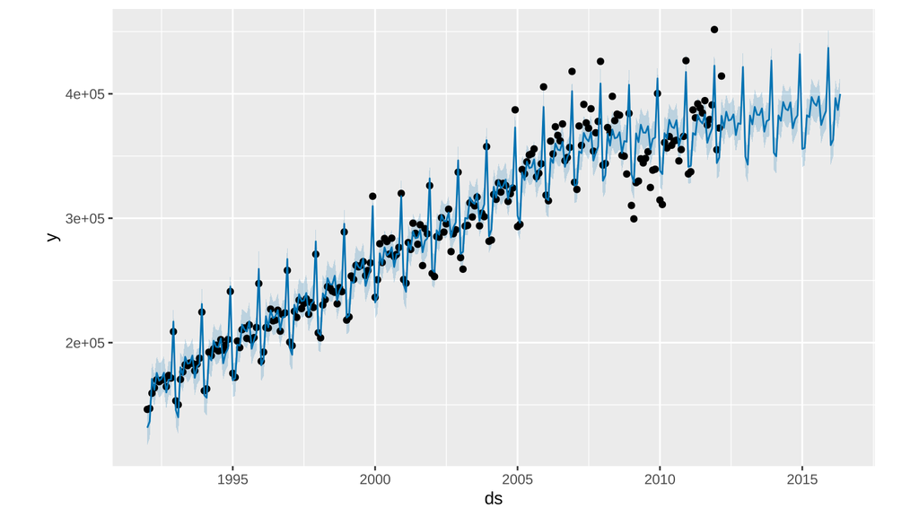

```r
retail_fcst <- p$value
plot(m, predict(m, data.frame(ds = retail$ds)))
```

### NNS model:

`NNS` uses the 12-month calendar lag and a linear regression of each lag’s components.

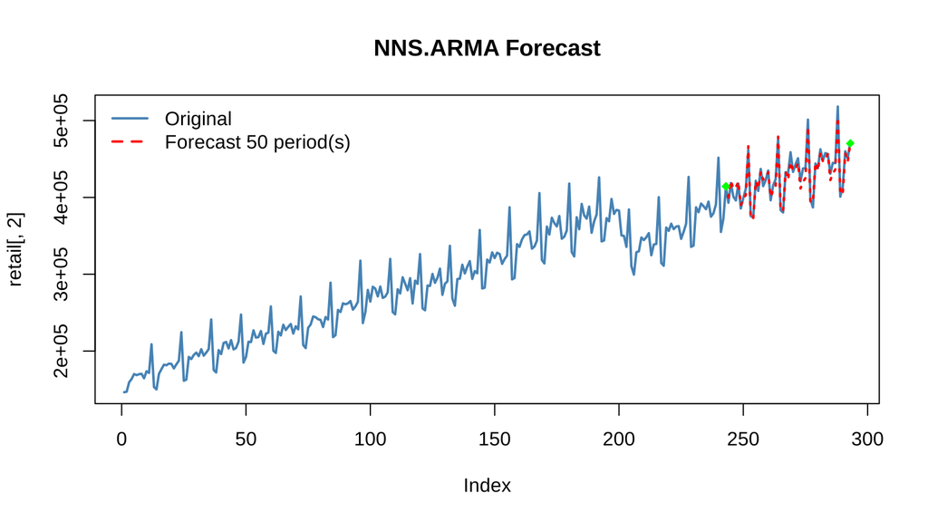

```r
n <- timed(NNS.ARMA(retail[, 2], h = 50, seasonal.factor = 12, method = 'lin',
                    training.set = l, seasonal.plot = FALSE))
```

```r
nns.retail.fcst <- n$value
```

### MSE:

```r
c(prophet = mean((retail_fcst$yhat - tail(retail[, 2], 50))^2),
  NNS = mean((nns.retail.fcst - tail(retail[, 2], 50))^2))
```

```
##    prophet        NNS
## 2369088008   52793721
```

```r
record("Retail sales", 50, retail_fcst$yhat, nns.retail.fcst, tail(retail[, 2], 50),
       retail[l, 2], c(p$seconds, n$seconds))
```

```
##   prophet RMSE NNS RMSE Last value RMSE
## 1     48673.28 7265.929        34167.38
```

## Peyton Manning Example (Raw Values)

```r
log_omaha <- read.csv(fetch(
  "https://raw.githubusercontent.com/facebook/prophet/main/examples/example_wp_log_peyton_manning.csv",
  "43a15e3f903a6e82cc0a53f0be249575"))
log_omaha$ds <- as.Date(log_omaha$ds)
omaha <- data.frame(ds = log_omaha$ds, y = exp(log_omaha$y))
range(omaha$ds)
```

```
## [1] "2007-12-10" "2016-01-20"
```

```r
sum(diff(omaha$ds) > 1)
```

```
## [1] 29
```

We are forecasting the last 365 periods…

```r
l <- length(omaha[, 1]) - 365
test_days <- omaha$ds[(l + 1):nrow(omaha)]
```

### prophet model:

```r
p <- timed({
  m <- prophet(omaha[1:l, ])
  predict(m, data.frame(ds = test_days))
})
```

```
## Disabling daily seasonality. Run prophet with daily.seasonality=TRUE to override this.
```

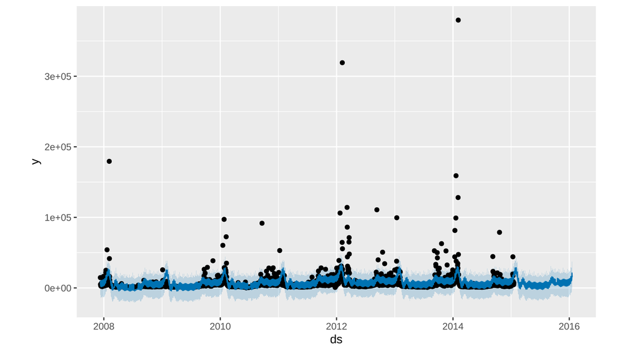

```r
omaha_fcst <- p$value
plot(m, predict(m, data.frame(ds = omaha$ds)))
```

### NNS model:

`NNS` is using a `seasonal.factor = c(1, sf)`, which translates to a daily and the best reported lag from our seasonality test on the training data. This is not optimized.

```r
sf <- NNS.seas(omaha[1:l, 2], plot = FALSE)$best.period
sf
```

```
## [1] 362
```

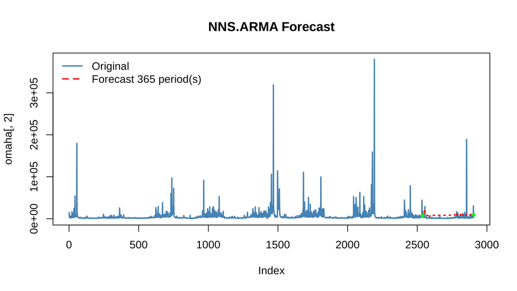

```r
n <- timed(NNS.ARMA(omaha[, 2], h = 365, seasonal.factor = c(1, sf), method = 'lin',
                    training.set = l, seasonal.plot = FALSE))
```

```r
nns.omaha.fcst <- n$value
```

### MSE:

```r
c(prophet = mean((omaha_fcst$yhat - tail(omaha[, 2], 365))^2),
  NNS = mean((nns.omaha.fcst - tail(omaha[, 2], 365))^2))
```

```
##   prophet       NNS
## 137562729 153994867
```

```r
record("Peyton Manning, raw", 365, omaha_fcst$yhat, nns.omaha.fcst, tail(omaha[, 2], 365),
       omaha[l, 2], c(p$seconds, n$seconds))
```

```
##   prophet RMSE NNS RMSE Last value RMSE
## 1     11728.71 12409.47        11938.17
```

## Peyton Manning Example (Log Values)

Using the log values of the preceding Peyton Manning dataset. Again, we are forecasting the last 365 periods…

### prophet model:

```r
p <- timed({
  m <- prophet(log_omaha[1:l, ])
  predict(m, data.frame(ds = test_days))
})
```

```
## Disabling daily seasonality. Run prophet with daily.seasonality=TRUE to override this.
```

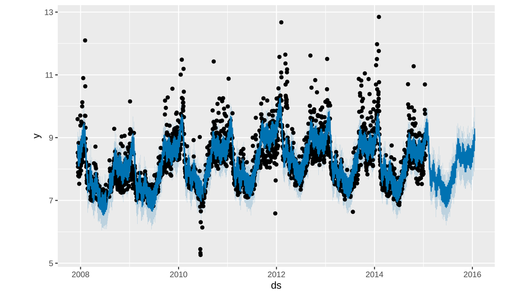

```r
log_omaha_fcst <- p$value
plot(m, predict(m, data.frame(ds = log_omaha$ds)))
```

### NNS model:

```r
sf <- NNS.seas(log_omaha[1:l, 2], plot = FALSE)$best.period
sf
```

```
## [1] 362
```

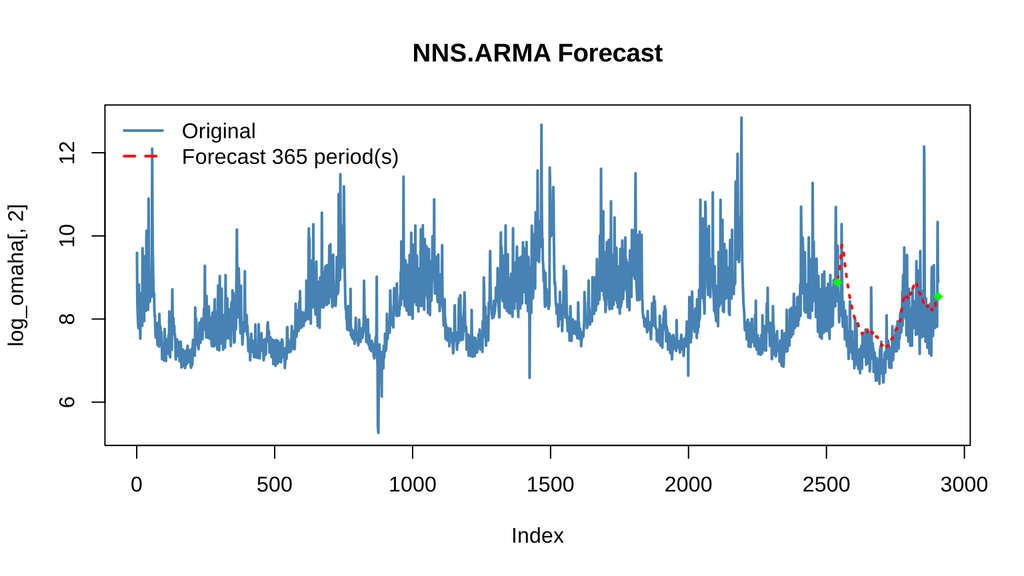

```r
n <- timed(NNS.ARMA(log_omaha[, 2], h = 365, seasonal.factor = c(1, sf), method = 'nonlin',
                    training.set = l, seasonal.plot = FALSE))
```

```r
nns.log.omaha.fcst <- n$value
```

### MSE:

```r
c(prophet = mean((log_omaha_fcst$yhat - tail(log_omaha[, 2], 365))^2),
  NNS = mean((nns.log.omaha.fcst - tail(log_omaha[, 2], 365))^2))
```

```
##   prophet       NNS
## 0.2874548 0.5636633
```

```r
record("Peyton Manning, log", 365, log_omaha_fcst$yhat, nns.log.omaha.fcst,
       tail(log_omaha[, 2], 365), log_omaha[l, 2], c(p$seconds, n$seconds))
```

```
##   prophet RMSE  NNS RMSE Last value RMSE
## 1    0.5361481 0.7507751        1.365399
```

### Notes

Can we recover better raw estimates from translated log estimates for `prophet`, or better log estimates from translated raw estimates for `NNS`? The exponent of a log forecast is a median-type forecast of the raw views, not their mean.

```r
c(`prophet, exp(log forecast) vs raw` = mean((exp(log_omaha_fcst$yhat) - tail(omaha[, 2], 365))^2),
  `prophet, raw forecast vs raw` = mean((omaha_fcst$yhat - tail(omaha[, 2], 365))^2))
```

```
## prophet, exp(log forecast) vs raw      prophet, raw forecast vs raw
##                         121964956                         137562729
```

```r
c(`NNS, log(raw forecast) vs log` = mean((log(nns.omaha.fcst) - tail(log_omaha[, 2], 365))^2),
  `NNS, log forecast vs log` = mean((nns.log.omaha.fcst - tail(log_omaha[, 2], 365))^2))
```

```
## NNS, log(raw forecast) vs log      NNS, log forecast vs log
##                     2.2861224                     0.5636633
```

## lynx Dataset

Next we test the Canadian lynx dataset suggested from Andrew Gelman’s blog post on prophet: http://andrewgelman.com/2017/03/01/facebooks-prophet-uses-stan/. The annual trappings from 1821 to 1934 are split into the first 80 years for training and the last 34 for testing.

```r
data(lynx)
l <- length(lynx) - 34
lynx_df <- data.frame(ds = as.Date(paste0(time(lynx), "-01-01")), y = as.numeric(lynx))
```

### prophet model and RMSE:

```r
p <- timed({
  m <- prophet(lynx_df[1:l, ])
  predict(m, data.frame(ds = lynx_df$ds[(l + 1):nrow(lynx_df)]))
})
```

```
## Disabling weekly seasonality. Run prophet with weekly.seasonality=TRUE to override this.
```

```
## Disabling daily seasonality. Run prophet with daily.seasonality=TRUE to override this.
```

```r
fcast <- p$value
sqrt(mean((tail(lynx, 34) - fcast$yhat)^2))
```

```
## [1] 1965.652
```

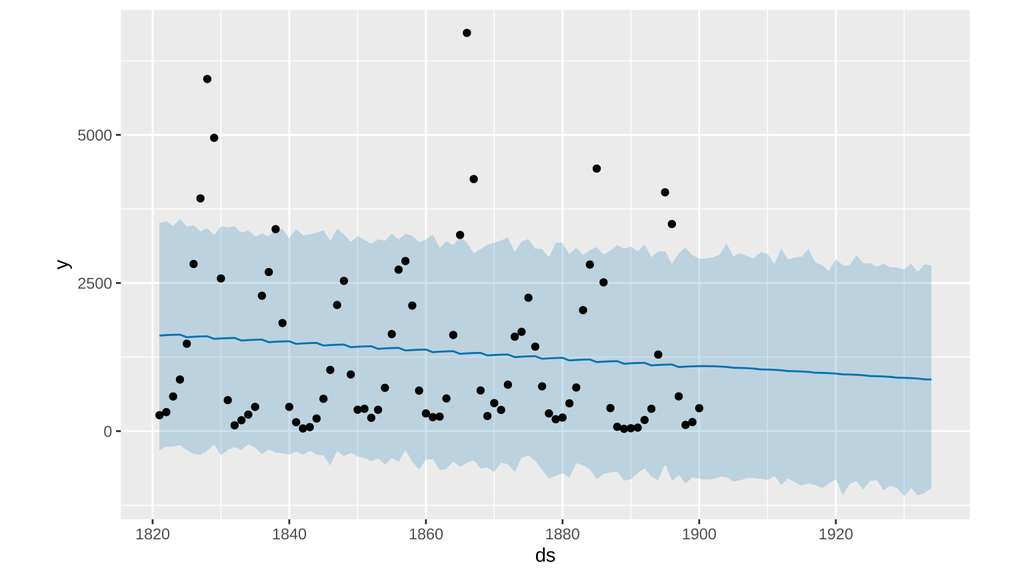

```r
plot(m, predict(m, data.frame(ds = lynx_df$ds)))
```

### NNS model and RMSE:

`NNS` uses the two best periods `NNS.seas` finds in the 80 training years.

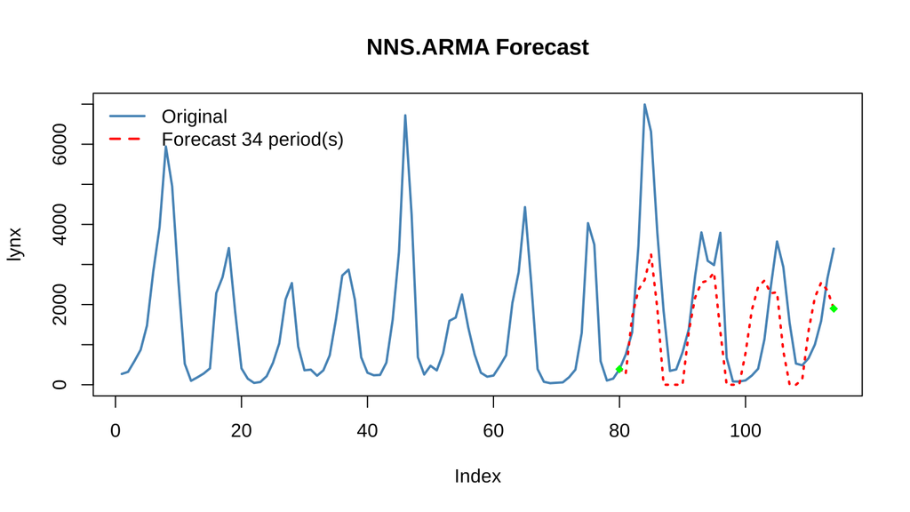

```r
n <- timed(NNS.ARMA(lynx, h = 34, training.set = l, method = 'lin', seasonal.factor = FALSE,
                    best.periods = 2, seasonal.plot = FALSE))
```

```r
nns.lynx <- n$value
sqrt(mean((nns.lynx - tail(lynx, 34))^2))
```

```
## [1] 1433.139
```

```r
record("lynx", 34, fcast$yhat, nns.lynx, tail(lynx, 34), lynx[l], c(p$seconds, n$seconds))
```

```
##   prophet RMSE NNS RMSE Last value RMSE
## 1     1965.652 1433.139        2338.895
```

## S&P 500

Finally we are going to forecast 252 trading days of the S&P 500 index, at three consecutive forecast origins. The archived page used SPY prices from 2007 to 2017 downloaded from Yahoo Finance with `quantmod`. This build uses FRED’s `SP500` series (index closes from S&P Dow Jones Indices), downloaded at build time; FRED keeps the most recent ten years. Each origin is trained on the 1260 trading days (about five years) before it, so the windows stay inside FRED’s range when the page is rebuilt, until late 2028.

```r
sp <- read.csv("https://fred.stlouisfed.org/graph/fredgraph.csv?id=SP500", na.strings = ".")
sp <- sp[!is.na(sp[[2]]), ]
sp <- data.frame(ds = as.Date(sp[[1]]), y = sp[[2]])
sp <- sp[sp$ds <= as.Date("2026-10-30"), ]
origins <- nrow(sp) - 252 * (3:1)
data.frame(Year = 1:3,
           `Training from` = sp$ds[origins - 1259], `Origin` = sp$ds[origins],
           `Test from` = sp$ds[origins + 1], `Test to` = sp$ds[origins + 252],
           check.names = FALSE)
```

```
##   Year Training from     Origin  Test from    Test to
## 1    1    2018-10-23 2023-10-25 2023-10-26 2024-10-25
## 2    2    2019-10-24 2024-10-25 2024-10-28 2025-10-29
## 3    3    2020-10-23 2025-10-29 2025-10-30 2026-10-30
```

`NNS` is using a `seasonal.factor = c(1, 5, 21, 63, 126, 252)`, which translates to a daily, weekly, monthly, quarterly, bi-annual and annual lag for S&P closing prices.

```
## Disabling daily seasonality. Run prophet with daily.seasonality=TRUE to override this.
```

```
##   prophet RMSE NNS RMSE Last value RMSE
## 1     432.4406 802.5419        1069.047
```

```
## Disabling daily seasonality. Run prophet with daily.seasonality=TRUE to override this.
```

```
##   prophet RMSE NNS RMSE Last value RMSE
## 1     581.0286 318.1865        461.1854
```

```
## Disabling daily seasonality. Run prophet with daily.seasonality=TRUE to override this.
```

```
##   prophet RMSE NNS RMSE Last value RMSE
## 1     334.0668 336.5259        512.4236
```

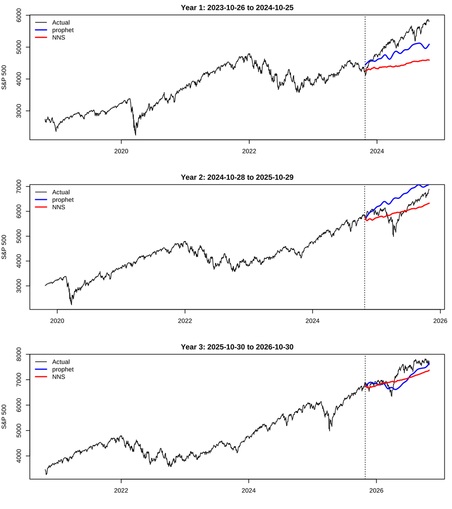

```r
par(mfrow = c(3, 1), mar = c(4, 4, 2, 1))
for (k in 1:3) {
  window <- (origins[k] - 1259):(origins[k] + 252)
  train <- sp[window[1:1260], ]
  test <- sp[window[1261:1512], ]
  p <- timed({
    m <- prophet(train)
    predict(m, data.frame(ds = test$ds))
  })
  n <- timed(NNS.ARMA(train$y, h = 252, seasonal.factor = c(1, 5, 21, 63, 126, 252),
                      method = 'nonlin', plot = FALSE, seasonal.plot = FALSE))
  print(record(paste0("S&P 500, year ", k), 252, p$value$yhat, n$value, test$y,
               tail(train$y, 1), c(p$seconds, n$seconds)))
  plot(c(train$ds, test$ds), c(train$y, test$y), type = "l", xlab = "", ylab = "S&P 500",
       main = paste0("Year ", k, ": ", test$ds[1], " to ", test$ds[252]))
  lines(test$ds, p$value$yhat, col = "blue", lwd = 2)
  lines(test$ds, n$value, col = "red", lwd = 2)
  abline(v = train$ds[1260], lty = 3)
  legend("topleft", legend = c("Actual", "prophet", "NNS"), col = c("black", "blue", "red"),
         lty = 1, lwd = c(1, 2, 2), bty = "n")
}
```

## Summary

```r
summary_table <- do.call(rbind, results)
knitr::kable(summary_table, digits = c(0, 0, 4, 4, 4, 1, 1), row.names = FALSE,
             caption = "Test RMSE and run time (seconds) of each forecast")
```

Test RMSE and run time (seconds) of each forecast

| Comparison | Horizon | prophet RMSE | NNS RMSE | Last value RMSE | prophet s | NNS s |
| --- | --- | --- | --- | --- | --- | --- |
| Retail sales | 50 | 48673.2782 | 7265.9288 | 34167.3821 | 1.8 | 0.0 |
| Peyton Manning, raw | 365 | 11728.7139 | 12409.4668 | 11938.1719 | 2.0 | 0.1 |
| Peyton Manning, log | 365 | 0.5361 | 0.7508 | 1.3654 | 1.6 | 3.6 |
| lynx | 34 | 1965.6522 | 1433.1391 | 2338.8946 | 0.6 | 0.0 |
| S&P 500, year 1 | 252 | 432.4406 | 802.5419 | 1069.0471 | 1.5 | 3.0 |
| S&P 500, year 2 | 252 | 581.0286 | 318.1865 | 461.1854 | 1.5 | 3.1 |
| S&P 500, year 3 | 252 | 334.0668 | 336.5259 | 512.4236 | 1.3 | 2.9 |

`NNS.ARMA` has the lower RMSE in 3 of these 7 forecasts and `prophet` in 4. The last-value forecast is more accurate than `prophet` in 2 and than `NNS.ARMA` in 1. Each `prophet` fit took 0.6 to 2.0 seconds here and each `NNS.ARMA` forecast 0.0 to 3.6 seconds.

These are single forecast origins for retail sales, Peyton Manning (raw and log) and lynx, and three consecutive years of the S&P 500, so they describe these windows rather than rank the methods. A ranking would need many origins per series, scored with the same data, origins, horizon and tuning budget for every method.

To be fair, `prophet` was not altered from its default settings and any interested readers are more than welcome to suggest different settings to improve performance. `NNS` was not optimized either.

> **Note (2026).** The archived page’s scores, including the running tally, came from test-window period selection (Peyton Manning), a misaligned lynx comparison and SPY data that cannot be reproduced; they are withdrawn. See `examples/example-corrections.md`.

Comments welcome at: ovvo.financial.systems@gmail.com

Further `NNS.ARMA` examples are available at: https://github.com/OVVO-Financial/NNS/blob/NNS-Beta-Version/examples/NNS%20ARMA.pdf

Thank you for your interest!